# Session 2

Lauren Yee

April 2nd, 2020

# Visualization and Reproducible Reports in R

## Session 2

### April 2nd, 2020

# Visualization and Reproducible Reports in R

## Presented By:

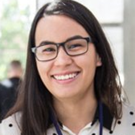

**Lauren Yee** is multifaceted researcher and data scientist. She currently works in the consulting industry and designs projects around data visualization, dashboards and ecological and spatial analysis.

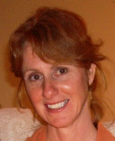

**Ann Greenwood** is the Education and Training Lead for Population Data BC. She manages a variety of education and training services for researchers and population health professionals . Services include an online certificate course in Population Health Data Analysis, live webinar-based courses, free online self -paced workshops, colloquium presentations/webinars and in-person workshops.

# Session 2

# Introduction to ggplot2

# ggplot2

**ggplot2** is a library in R used to visualize and plot data, included in the tidyverse package.

- **ggplot2** implements the *grammar of graphics* which is a system for describing and building graphs.
- allows you to build graphics with a lot of freedom and is easy to learn the “grammar”
- avoids common pitfalls through lack of functionality or warning messages:
  - 3D Graphics
  - Pie Charts
  - Dual axes
  - long/overlapping labels

# Components of the Layered Grammar

- data and aesthetic mappings
- geometric objects
- scales
- statistics and transformations
- a coordinate system
- facet specification
- themes

The data, mappings, statistical transformation, and geometric object form a layer. A plot can have multiple layers when such as when we overlay a scatter plot with a smoothed line

**scales** map values from the data to aesthetics **of** the data, such as: colour, size or shape, the legend, or an axis.

**coordinate systems** are how the data is mapped to the plot on the screen. By default this is usually Cartesian coordinate system but polar coordinates and map projections can also be used.

**faceting** is used to generate many of the same types of plots based on categories of your data. Also known as latticing/trellising.

**themes** are the actual visuals of the plot, not linked to data. Axis labels, rotation of labels, colour, font, grid lines, etc.

# Layer:geoms

A layer combines data, aesthetic mapping, a `geom_`, a stat and position argument. There are many types of `geoms_` and each have a unique specification and requirements.

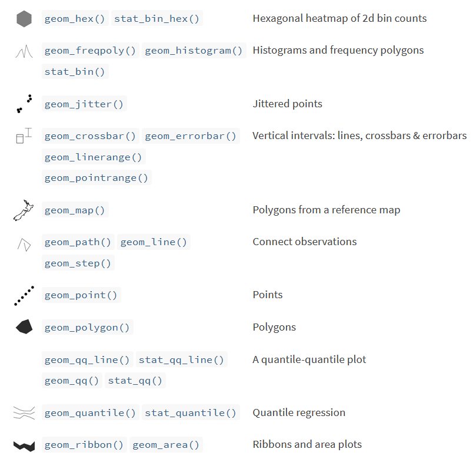

…and many more.

Within a `geom_` is also *statistics*, each `geom_` has a default statistic.

# ggplot2

To call a plot in r we start with `ggplot()` Then we need to supply the *data* we are mapping to the plot. `ggplot(data=mpg)`.

`aes()` is the aesthetic mappings `ggplot(data=mt_cars, aes())`

Then we can add objects and layers with a `+` and the *type* of layer geom_

```r
ggplot(data = mpg) +
  geom_point(mapping = aes(x = displ, y = hwy))
```

# Examples

Using the `mpg` **data frame** in ggplot2.

| manufacturer | model | displ | year | cyl | trans | drv | cty | hwy | fl | class |
| --- | --- | --- | --- | --- | --- | --- | --- | --- | --- | --- |
| audi | a4 | 1.8 | 1999 | 4 | auto(l5) | f | 18 | 29 | p | compact |
| audi | a4 | 1.8 | 1999 | 4 | manual(m5) | f | 21 | 29 | p | compact |
| audi | a4 | 2.0 | 2008 | 4 | manual(m6) | f | 20 | 31 | p | compact |
| audi | a4 | 2.0 | 2008 | 4 | auto(av) | f | 21 | 30 | p | compact |
| audi | a4 | 2.8 | 1999 | 6 | auto(l5) | f | 16 | 26 | p | compact |
| audi | a4 | 2.8 | 1999 | 6 | manual(m5) | f | 18 | 26 | p | compact |

Among the variables in mpg are:

1. *displ*, a car’s engine size, in litres.
2. *hwy*, a car’s fuel efficiency on the highway, in miles per gallon (mpg). A car with a low fuel efficiency consumes more fuel than a car with a high fuel efficiency when they travel the same distance.

# Plotting

Do cars with big engines use more fuel than cars with small engines?

Recall that:

1. We need to supply the *data* to the plot. This is *mpg*.
2. `aes()` is the aesthetic mappings we are mapping *hwy* and *displ*
3. The *geom_point* is used to create scatterplots.

```r
ggplot(data = mpg) +
  geom_point(mapping = aes(x = displ, y = hwy))
```

The `x` and `y` arguments of `aes()` specify which variables to map to the x and y axes. ggplot2 looks for these variables in the data argument (mpg).

# We can also write:

```r
ggplot(data=mpg, aes(x=displ,y=hwy))+
  geom_point()
```

This is because `ggplot()` is ‘globally defined’ so any geom_ preceding it can inherit what is inside of the `ggplot` parentheses.

You can also define data in the geom_

```r
ggplot()+
  geom_point(data=mpg,aes(x=displ,y=hwy))
```

# Assign `ggplot()` as a variable

Assigning a plot to a variable allows you to interact with, and add to the plot.

```r
plot <- ggplot(data=mpg, aes(x=displ,y=hwy))
plot +
  geom_point()
```

The convention we will use for this workshop is:

```r
ggplot(data=mpg, aes(x=displ,y=hwy))+
  geom_point()
```

# Aesthetics

- Add colour to `aes()` further examine relationships from a variable *within* the data
- Add colour outside of `aes()` to define one colour for the data contained in the `geom_`

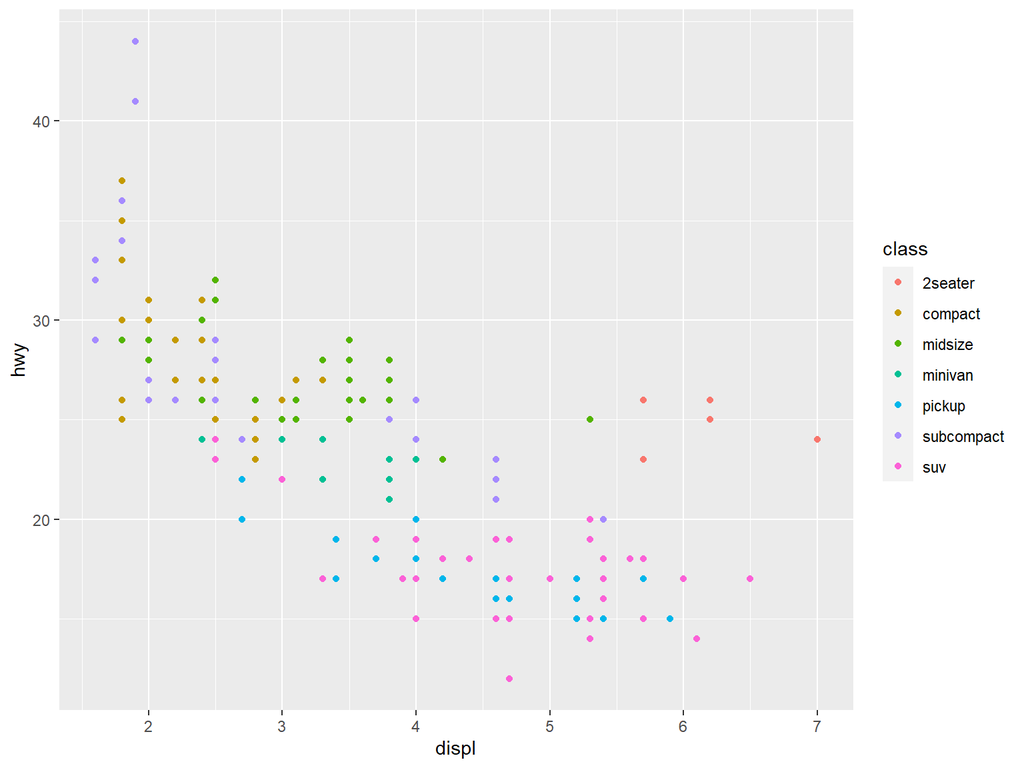

```r
ggplot(data=mpg, aes(x=displ,y=hwy,colour=class))+
  geom_point()
```

# Outside aes

A common error in ggplot2 is putting `colour` or `fill` in the wrong place. Class is contained within `mpg`, so if we want to map the *aes*thetics to the data it needs to be within the brackets. Otherwise, outside the brackets ggplot does not know how to interpret this :

```r
ggplot(data=mpg, aes(x=displ,y=hwy),colour=class)+
  geom_point()
```

Alternatively, if we want everything to be one colour we can define the colour outside of aes or within our geom_

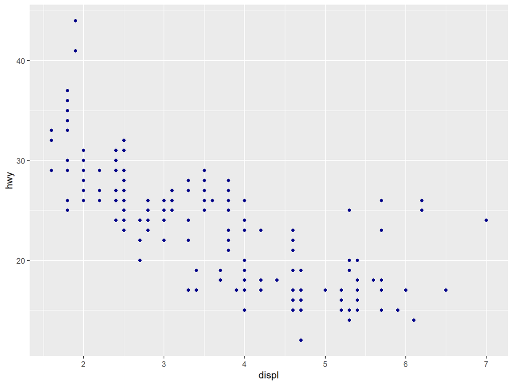

```r
ggplot(data=mpg, aes(x=displ,y=hwy))+
    geom_point(color="darkblue")
```

*Note adding `color="darkblue"` to the global `ggplot2` will not work

[figure not shown]

# Size

The size of the plot objects can also be changed to scale with their values. Also known as a “bubble chart”

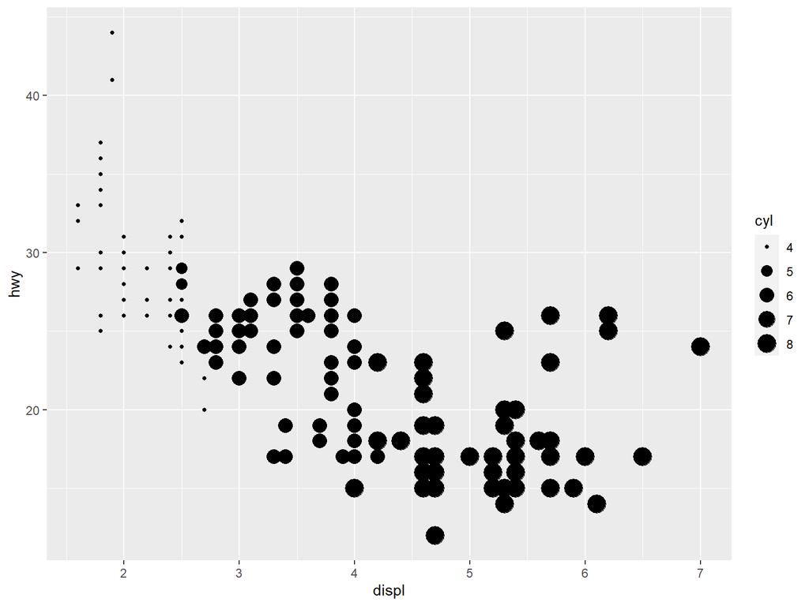

```r
ggplot(data=mpg, aes(x=displ,y=hwy,size=cyl))+
    geom_point()
```

Alter transparency by adding an `alpha` parameter to `geom_point()`. *Alpha* ranges from 0-1. Adding `alpha` adds to `ggplot()` adds a legend that we don’t want

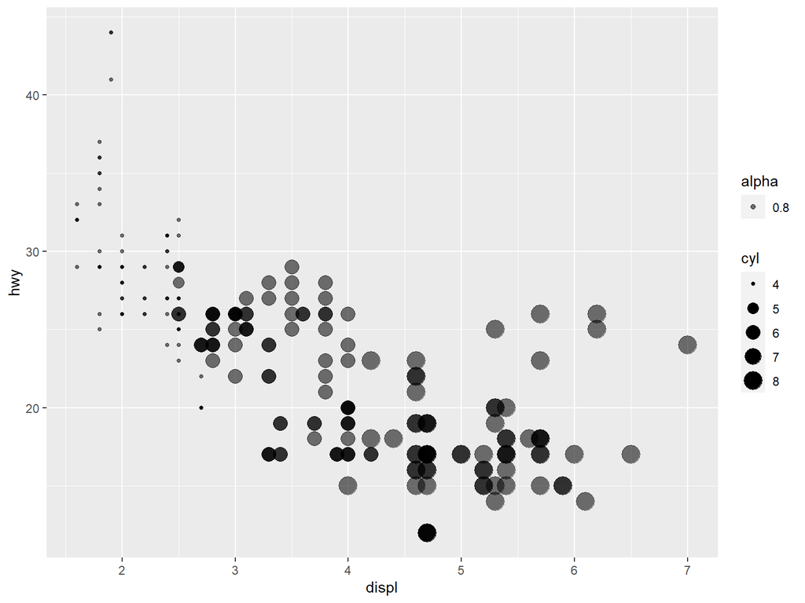

```r
ggplot(data=mpg, aes(x=displ,y=hwy,size=cyl,alpha=0.8))+
    geom_point()
```

So we add the aesthetic to geom_point

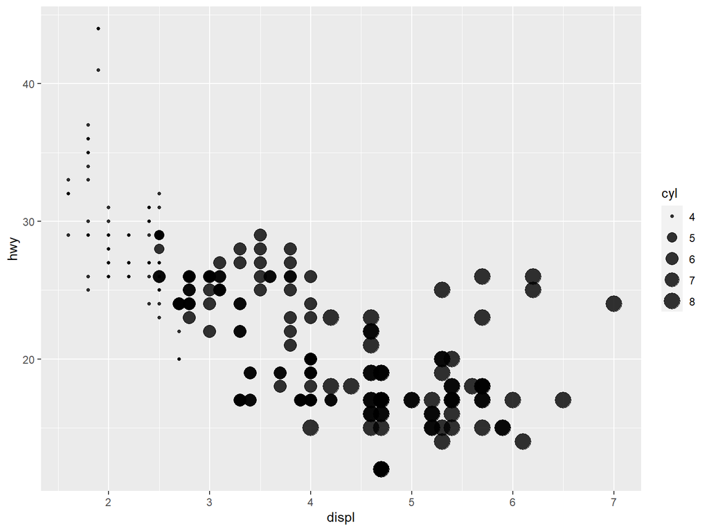

```r
ggplot(data=mpg, aes(x=displ,y=hwy,size=cyl))+
    geom_point(alpha=0.8)
```

Alternatively

```r
ggplot(data=mpg)+
    geom_point(aes(x=displ,y=hwy,size=cyl),alpha=0.8)
```

# Conditions

ggplot can use colours and conditions to output into your plot. Assign colours based on the values of cyl that are greater than 7

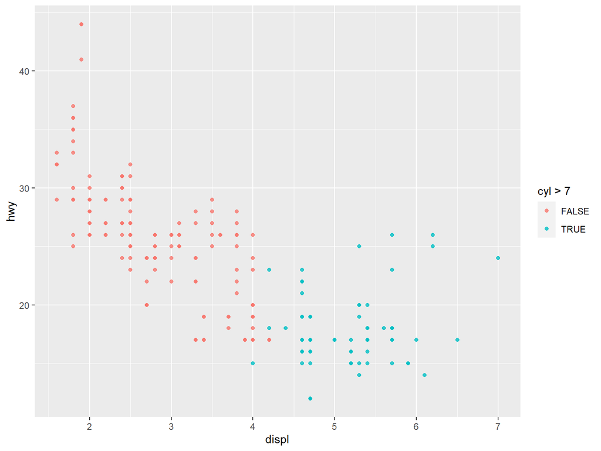

```r
ggplot(data=mpg,aes(x=displ,y=hwy,colour=cyl > 7))+
    geom_point(alpha=0.8)
```

# Shape

Recall the types of available shapes:

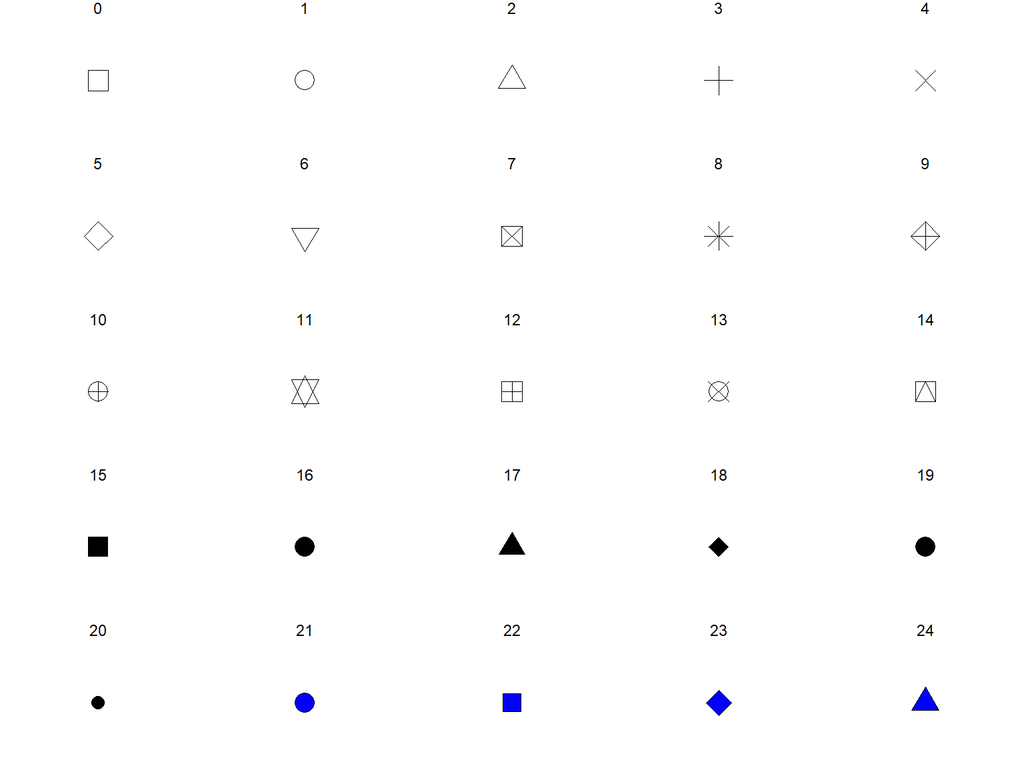

```
## Warning: The shape palette can deal with a maximum of 6 discrete values because
## more than 6 becomes difficult to discriminate; you have 7. Consider
## specifying shapes manually if you must have them.
```

```
## Warning: Removed 62 rows containing missing values (geom_point).
```

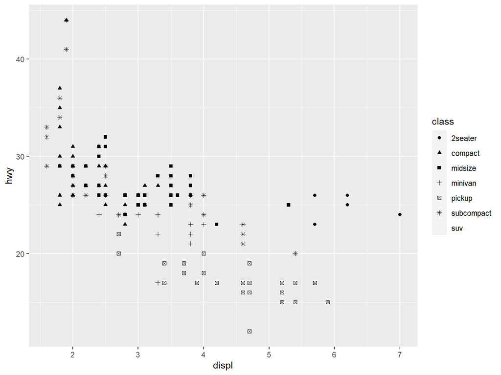

```r
ggplot(data=mpg, aes(x=displ,y=hwy,shape=class))+
    geom_point()
```

Notice that we get a warning here, `ggplot2` will only plot a maximum of 6 different shapes by default.

`ggplot2` has built in data visualization principles.

# Shape

To assign one shape to **all the points** we assign it to the geom

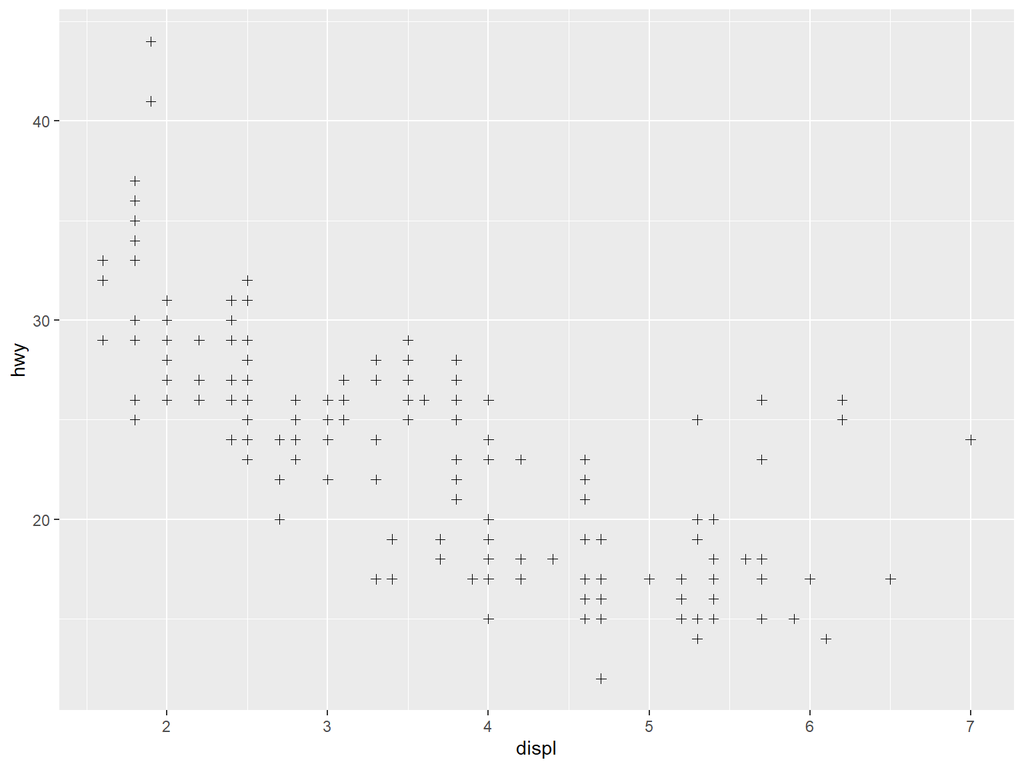

```r
ggplot(data=mpg, aes(x=displ,y=hwy))+
    geom_point(shape=3)
```

# Bar Charts

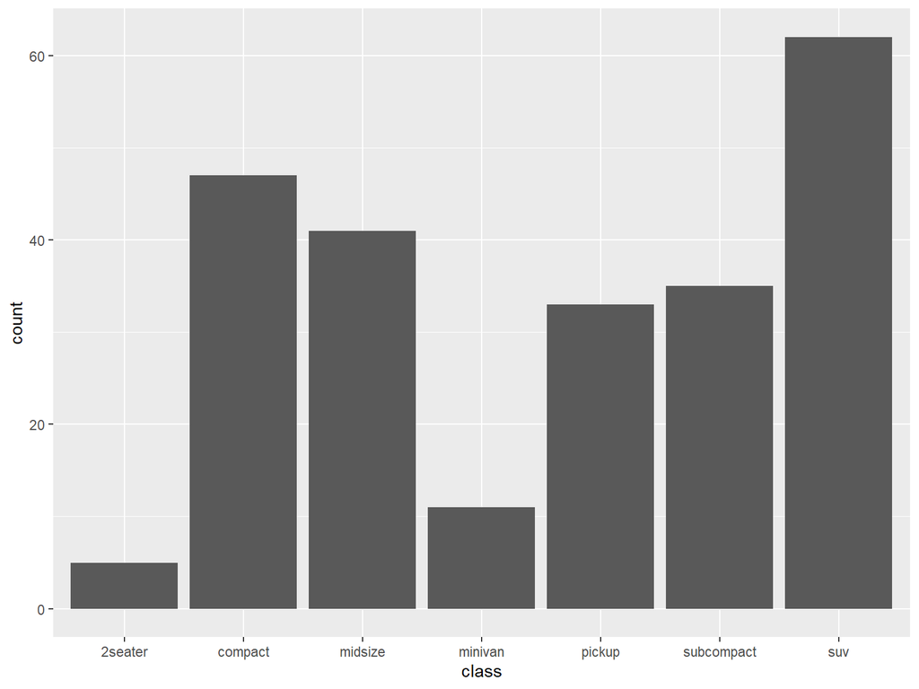

```r
ggplot(data=mpg, aes(x=class))+
    geom_bar()
```

`geom_bar()` uses `stat_count()` by default. If we pre-computed our data and already have the total count then we specify `identity`.

```r
mpg %>%
  group_by(class)%>%
  count()
```

```
## # A tibble: 7 x 2
## # Groups:   class [7]
##   class          n
##   <chr>      <int>
## 1 2seater        5
## 2 compact       47
## 3 midsize       41
## 4 minivan       11
## 5 pickup        33
## 6 subcompact    35
## 7 suv           62
```

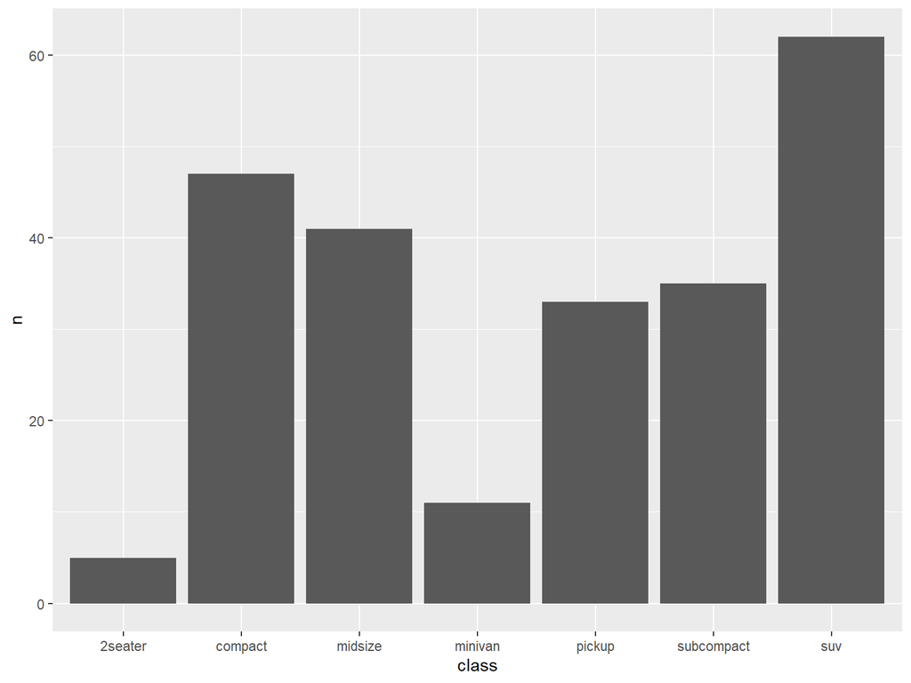

```r
mpg %>%
  group_by(class)%>%
  count()%>%
  ggplot()+
  geom_bar(aes(x=class,y=n), stat = "identity")
```

# Stacking Layers

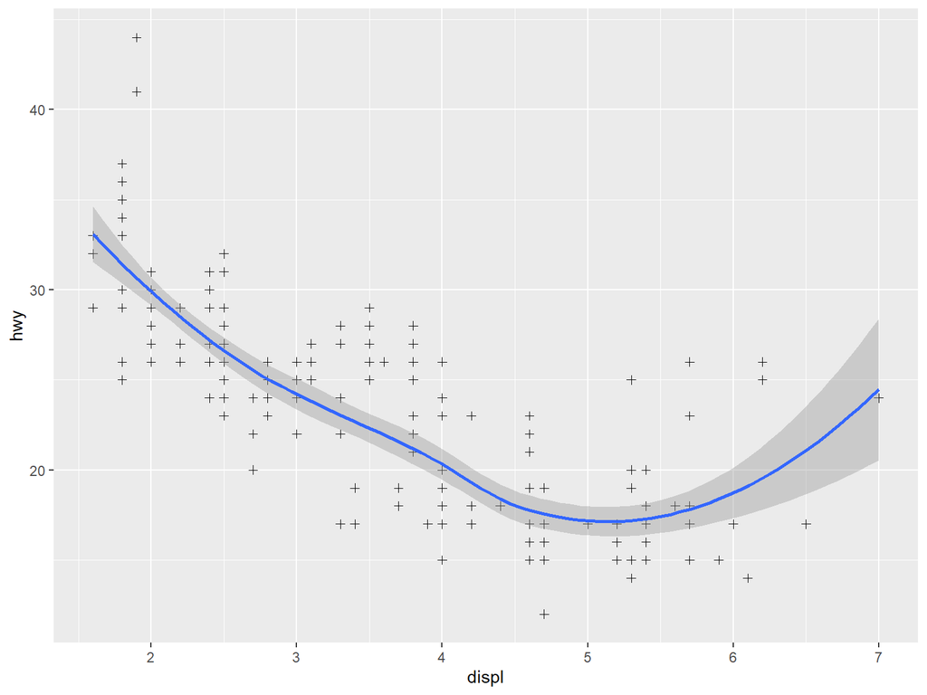

```r
ggplot(data=mpg, aes(x=displ,y=hwy))+
    geom_point(shape=3)+
  geom_smooth()
```

# Scales

Change the color scale using the discrete viridis scale

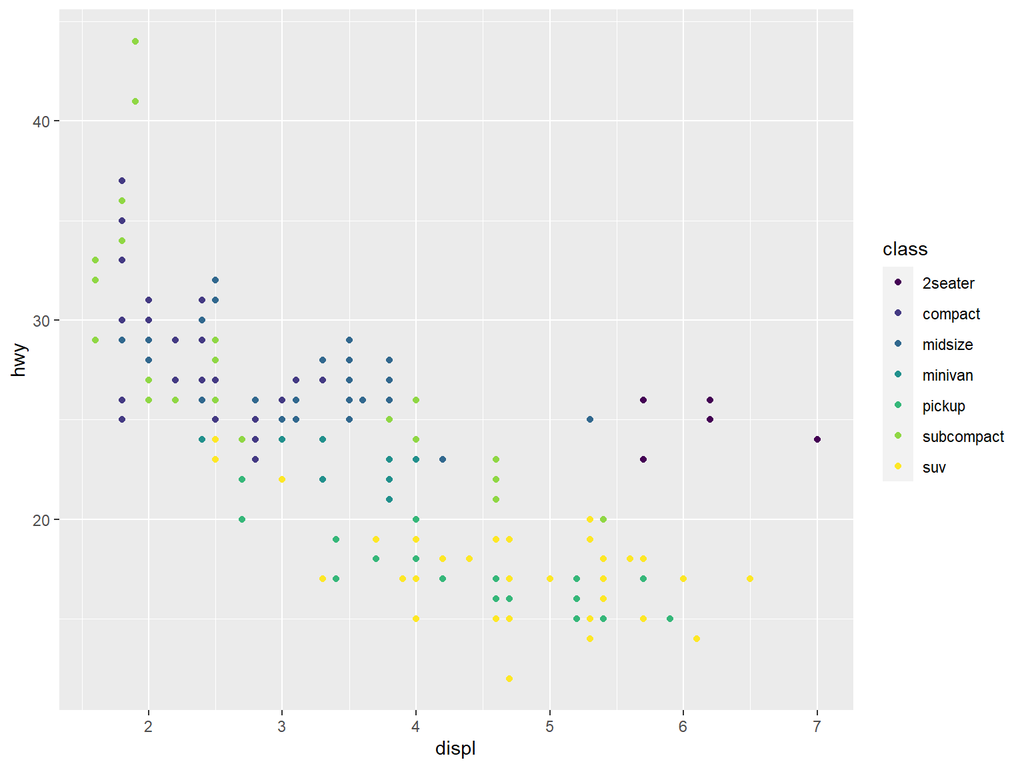

```r
ggplot(data=mpg) +
  geom_point(aes(x= displ,y=hwy, colour=class))+
  scale_color_viridis_d()
```

Change the scale of the x and y axis

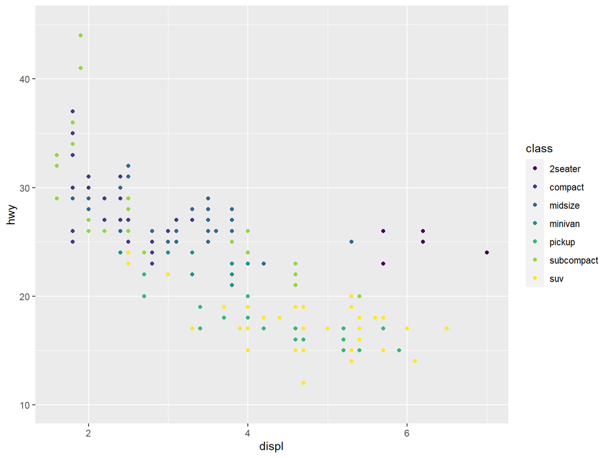

```r
ggplot(data=mpg) +
  geom_point(aes(x= displ,y=hwy, colour=class))+
  scale_color_viridis_d()+
  scale_x_continuous(breaks=c(2,4,6)) +
  scale_y_continuous(limits=c(10,45))
```

Within the scales, we can specify the breaks on the x-axis to label. On the y-axis `limits` sets the minimum value to 10 and maximum to 45.

Since our y scale is continuous we can alter the breaks using `scale_y_continuous`. `seq` is starting a *sequence* at 5, going to 45 and increasing by an interval of *5*. Our breaks should occur at `5, 5+5 = 10, 10+5=15`…etc

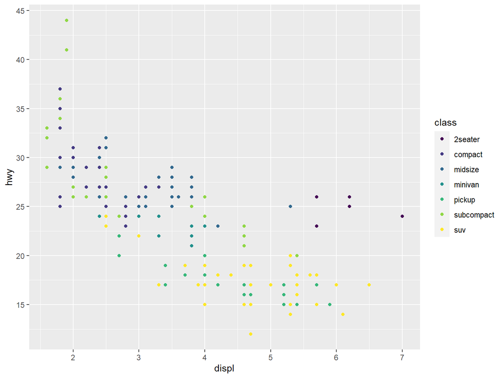

# Themes

# Themes

## Labels

`labs` can specify the axis labels, title, caption, fill, colour and shape *labels*

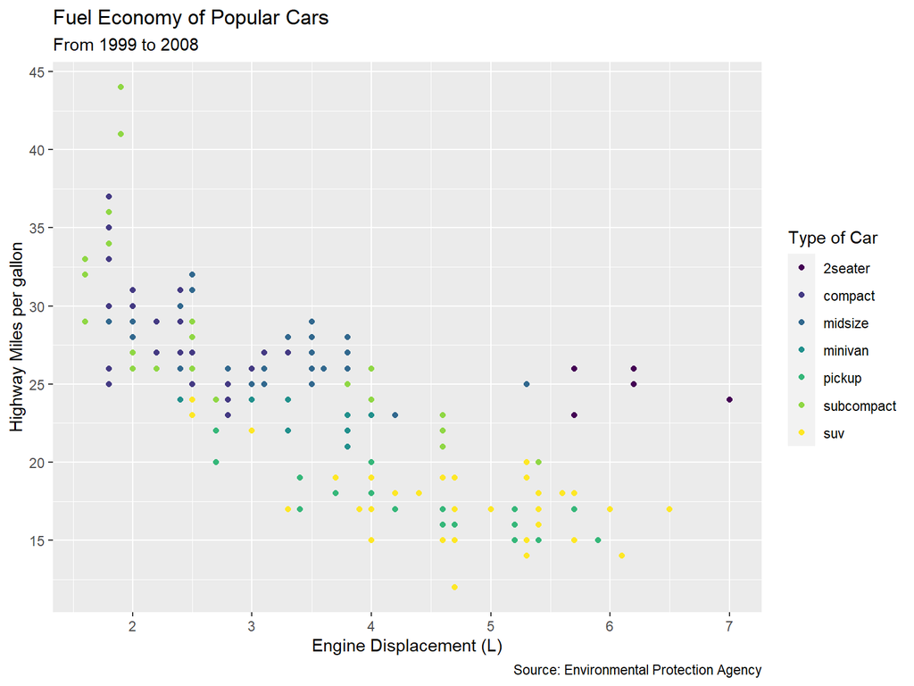

```r
ggplot(data=mpg) +
  geom_point(aes(x= displ,y=hwy, colour=class))+
  scale_color_viridis_d()+
   scale_y_continuous(breaks = seq(5, 45, by = 5))+
  labs(x="Engine Displacement (L)",y="Highway Miles per gallon", colour="Type of Car",
       title="Fuel Economy of Popular Cars", subtitle = "From 1999 to 2008",
       caption="Source: Environmental Protection Agency")
```

# Preset Themes

There are a few preset themes in R

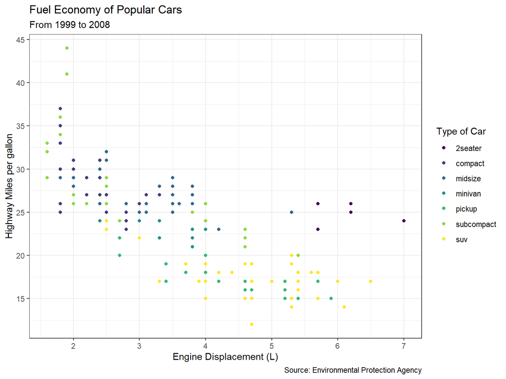

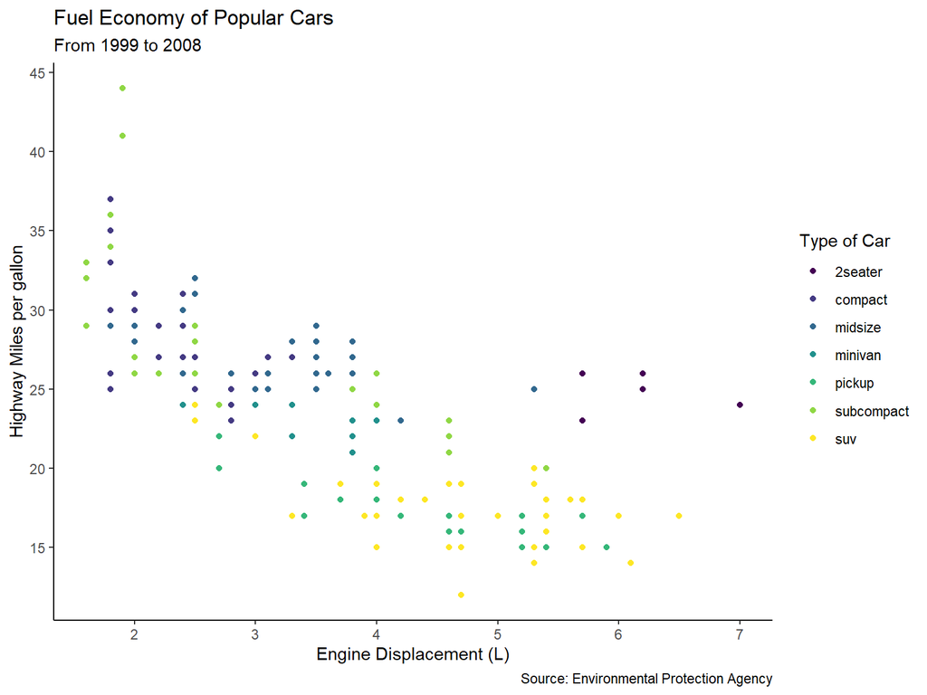

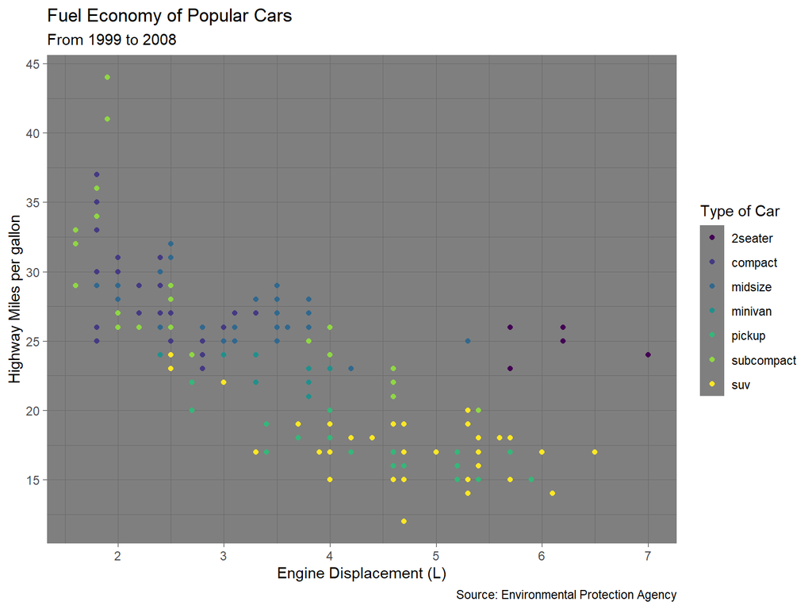

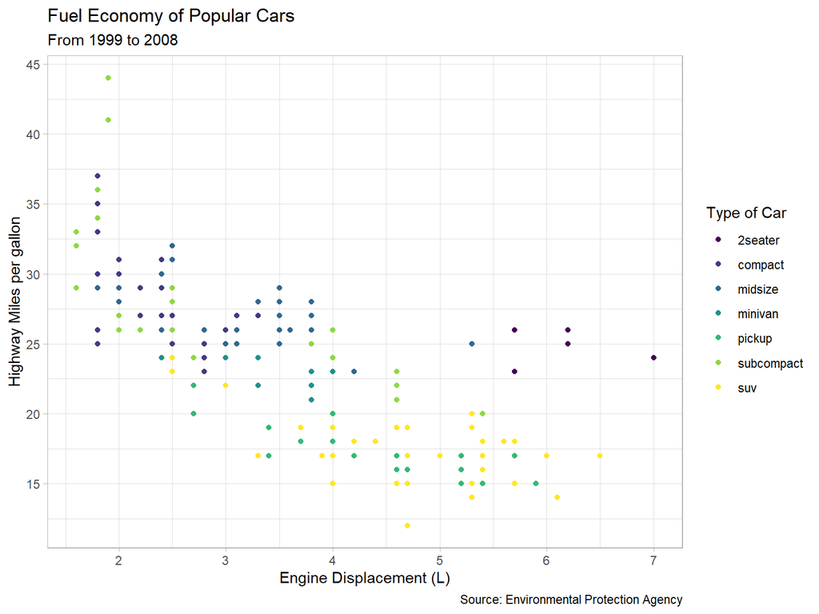

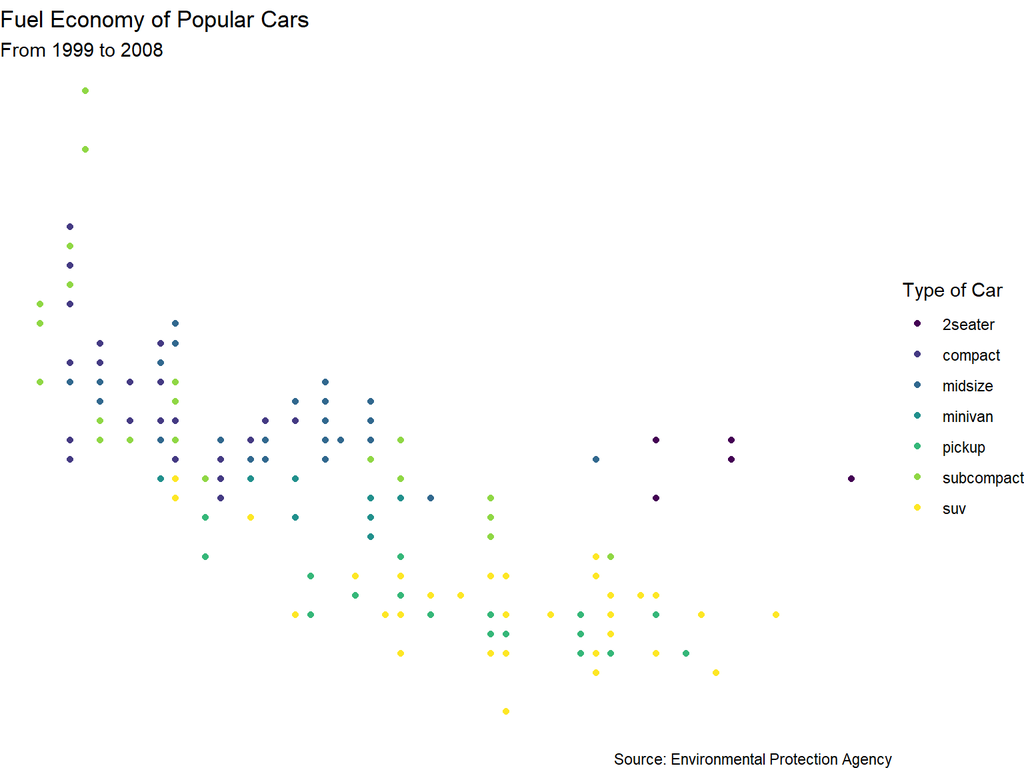

# Theme_bw

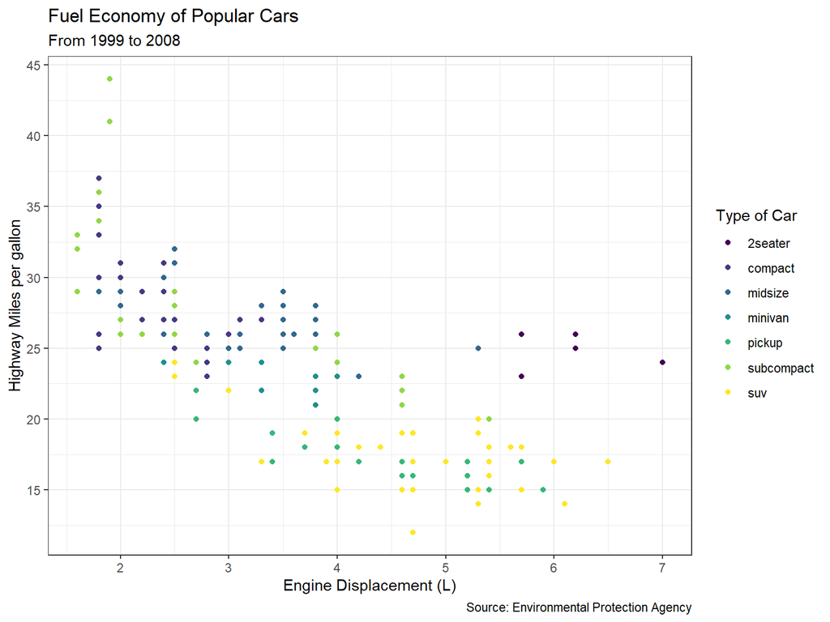

```r
p + theme_bw()
```

# Theme_classic

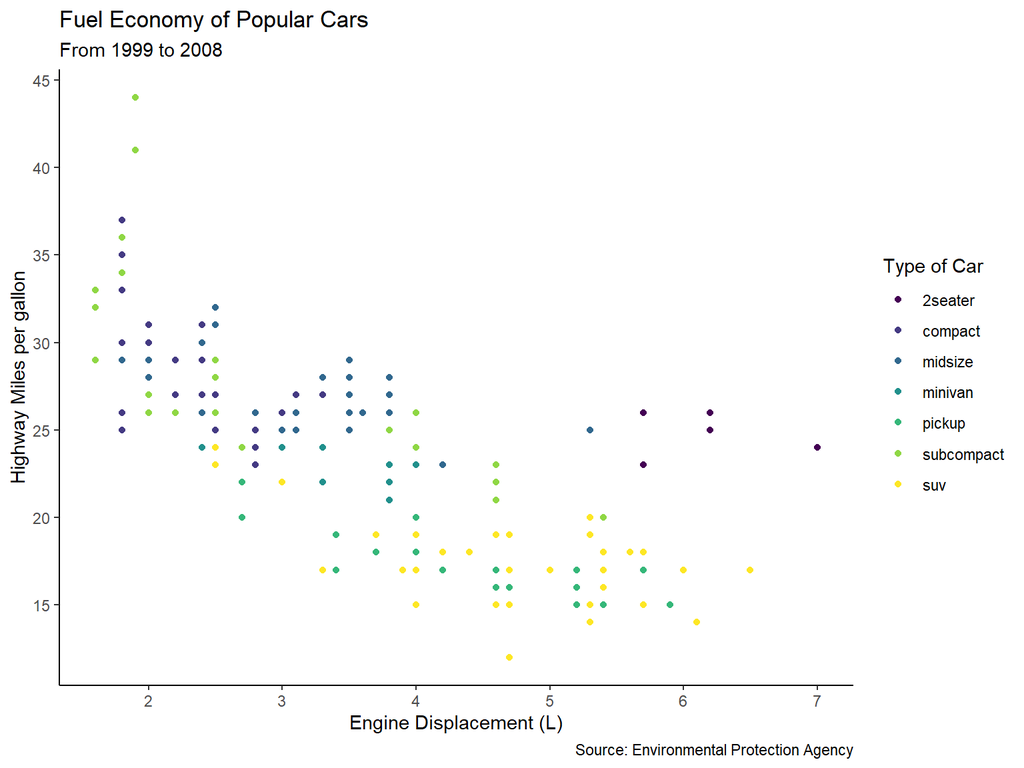

```r
p+ theme_classic()
```

# Theme_dark

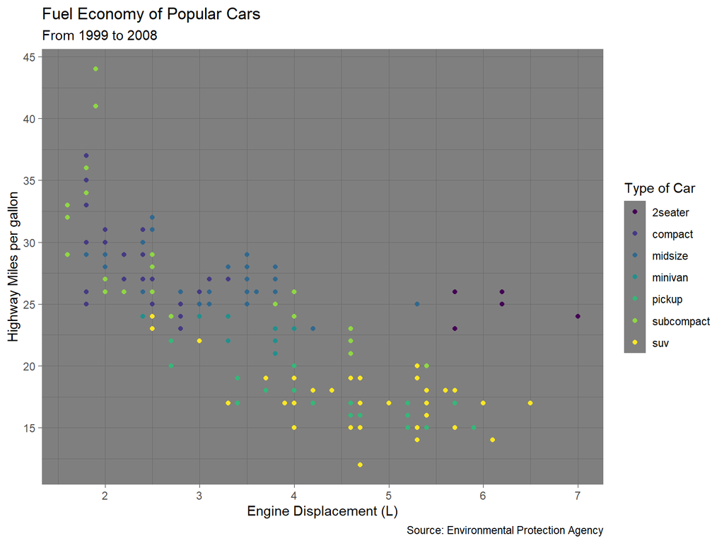

```r
p+ theme_dark()
```

# Theme_light

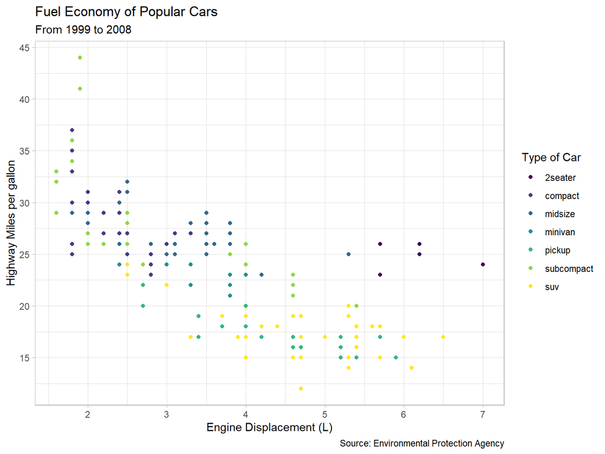

```r
p+ theme_light()
```

# Theme_void

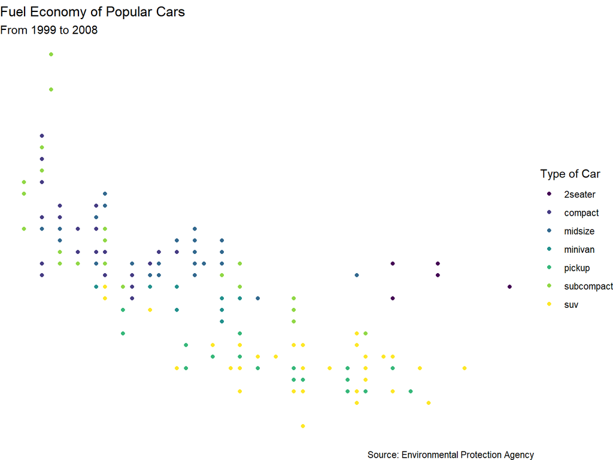

```r
p+ theme_void()
```

# Saving

There are a lot of ways to save a plot `ggsave()` will save the most recent plot. In R Markdown, we have already specified all figures will be saved in the `Figs` directory by their chunk name.

# Sources

http://vita.had.co.nz/papers/layered-grammar.pdf

https://ggplot2.tidyverse.org/

https://r4ds.had.co.nz/data-visualisation.html